# Part I - (Dataset Exploration Title)

## Introduction

#### Dataset:

> Dataset Name: Flights dataset, this dataset used in my project from classroom

> Purpose: The main goal of this analysis is to understand the most repeated destinations , time periods and all airlines of planes.

## Preliminary Wrangling

#### Before importing needed packages i want to upgrade them

```python
%pip install --upgrade numpy pandas matplotlib seaborn
```

```python
# import all packages and set plots to be embedded inline
import numpy as np
import pandas as pd
import matplotlib.pyplot as plt
import seaborn as sns
pd.set_option('display.max_columns' , None)
```

#### Downloading compressed dataset to my workspace

```python
# import requests , os

# response = requests.get('https://video.udacity-data.com/topher/2023/December/6571fb88_airline_2m.tar/airline_2m.tar.gz')
# if not os.path.exists('Csv_Files/airline_2m.tar.gz'):
#     print('Downloading the dataset file')
#     with open('Csv_Files/airline_2m.tar.gz' , 'wb') as f:
#         f.write(response.content)

# I  have commented the above code because I have already downloaded the dataset file and it take about 10 minutes to check of exsitance of the file
```

#### loading dataset

```python
df = pd.read_csv('Csv_Files/airline_2m.tar.gz' , encoding='Latin-1' , low_memory=True)
```

#### Defining our dataset

```python
df.info(verbose = True , show_counts = True)
```

```
<class 'pandas.core.frame.DataFrame'>
RangeIndex: 2000000 entries, 0 to 1999999
Data columns (total 109 columns):
 #    Column                           Non-Null Count    Dtype
---   ------                           --------------    -----
 0    Year                             2000000 non-null  int64
 1    Quarter                          2000000 non-null  int64
 2    Month                            2000000 non-null  int64
 3    DayofMonth                       2000000 non-null  int64
 4    DayOfWeek                        2000000 non-null  int64
 5    FlightDate                       2000000 non-null  object
 6    Reporting_Airline                2000000 non-null  object
 7    DOT_ID_Reporting_Airline         2000000 non-null  int64
 8    IATA_CODE_Reporting_Airline      2000000 non-null  object
 9    Tail_Number                      1608237 non-null  object
```

[output cut: 101 more lines]

```python
df.describe()
```

|  | Year | Quarter | Month | DayofMonth | DayOfWeek | DOT_ID_Reporting_Airline | Flight_Number_Reporting_Airline | OriginAirportID | OriginAirportSeqID | OriginCityMarketID | OriginStateFips | OriginWac | DestAirportID | DestAirportSeqID | DestCityMarketID | DestStateFips | DestWac | CRSDepTime | DepTime | DepDelay | DepDelayMinutes | DepDel15 | DepartureDelayGroups | TaxiOut | WheelsOff | WheelsOn | TaxiIn | CRSArrTime | ArrTime | … |
| --- | --- | --- | --- | --- | --- | --- | --- | --- | --- | --- | --- | --- | --- | --- | --- | --- | --- | --- | --- | --- | --- | --- | --- | --- | --- | --- | --- | --- | --- | --- |
| count | 2.000000e+06 | 2.000000e+06 | 2.000000e+06 | 2.000000e+06 | 2.000000e+06 | 2.000000e+06 | 2.000000e+06 | 2.000000e+06 | 2.000000e+06 | 2.000000e+06 | 1.999354e+06 | 2.000000e+06 | 2.000000e+06 | 2.000000e+06 | 2.000000e+06 | 1.999406e+06 | 2.000000e+06 | 2.000000e+06 | 1.963995e+06 | 1.963932e+06 | 1.963932e+06 | 1.963932e+06 | 1.963932e+06 | 1.584358e+06 | 1.584323e+06 | 1.582042e+06 | 1.582153e+06 | 2.000000e+06 | 1.960449e+06 | … |
| mean | 2.004314e+03 | 2.501267e+00 | 6.500761e+00 | 1.572202e+01 | 3.937445e+00 | 1.992450e+04 | 1.719375e+03 | 1.271899e+04 | 1.271901e+06 | 3.173373e+04 | 2.687446e+01 | 5.522946e+01 | 1.271924e+04 | 1.271925e+06 | 3.173239e+04 | 2.685666e+01 | 5.526029e+01 | 1.332350e+03 | 1.343248e+03 | 8.587405e+00 | 1.049667e+01 | 1.696362e-01 | 6.643356e-02 | 1.580659e+01 | 1.362872e+03 | 1.479911e+03 | 6.714089e+00 | 1.492285e+03 | 1.487321e+03 | … |
| std | 9.228930e+00 | 1.118022e+00 | 3.443460e+00 | 8.778412e+00 | 1.990369e+00 | 3.665827e+02 | 1.659726e+03 | 1.534529e+03 | 1.534527e+05 | 1.302432e+03 | 1.643874e+01 | 2.682221e+01 | 1.534860e+03 | 1.534858e+05 | 1.302004e+03 | 1.643312e+01 | 2.678134e+01 | 4.765702e+02 | 4.818427e+02 | 3.272473e+01 | 3.196467e+01 | 3.753130e-01 | 1.824514e+00 | 1.023564e+01 | 4.855511e+02 | 5.065056e+02 | 7.948352e+00 | 4.955542e+02 | 5.062998e+02 | … |
| min | 1.987000e+03 | 1.000000e+00 | 1.000000e+00 | 1.000000e+00 | 1.000000e+00 | 1.938600e+04 | 1.000000e+00 | 1.013500e+04 | 1.013501e+06 | 3.007000e+04 | 1.000000e+00 | 1.000000e+00 | 1.013500e+04 | 1.013501e+06 | 3.007000e+04 | 1.000000e+00 | 1.000000e+00 | 0.000000e+00 | 1.000000e+00 | -9.900000e+02 | 0.000000e+00 | 0.000000e+00 | -2.000000e+00 | 0.000000e+00 | 1.000000e+00 | 1.000000e+00 | 0.000000e+00 | 0.000000e+00 | 1.000000e+00 | … |
| 25% | 1.997000e+03 | 1.000000e+00 | 3.000000e+00 | 8.000000e+00 | 2.000000e+00 | 1.970400e+04 | 5.220000e+02 | 1.129200e+04 | 1.129202e+06 | 3.064700e+04 | 1.200000e+01 | 3.400000e+01 | 1.129200e+04 | 1.129202e+06 | 3.064700e+04 | 1.200000e+01 | 3.400000e+01 | 9.250000e+02 | 9.300000e+02 | -3.000000e+00 | 0.000000e+00 | 0.000000e+00 | -1.000000e+00 | 1.000000e+01 | 9.440000e+02 | 1.105000e+03 | 4.000000e+00 | 1.115000e+03 | 1.111000e+03 | … |
| 50% | 2.005000e+03 | 3.000000e+00 | 7.000000e+00 | 1.600000e+01 | 4.000000e+00 | 1.980500e+04 | 1.170000e+03 | 1.289200e+04 | 1.289201e+06 | 3.145300e+04 | 2.600000e+01 | 5.200000e+01 | 1.289200e+04 | 1.289201e+06 | 3.145300e+04 | 2.600000e+01 | 5.200000e+01 | 1.325000e+03 | 1.331000e+03 | 0.000000e+00 | 0.000000e+00 | 0.000000e+00 | 0.000000e+00 | 1.300000e+01 | 1.344000e+03 | 1.513000e+03 | 5.000000e+00 | 1.520000e+03 | 1.518000e+03 | … |
| 75% | 2.012000e+03 | 3.000000e+00 | 9.000000e+00 | 2.300000e+01 | 6.000000e+00 | 2.035500e+04 | 2.211000e+03 | 1.405700e+04 | 1.405702e+06 | 3.257500e+04 | 4.200000e+01 | 8.100000e+01 | 1.405700e+04 | 1.405702e+06 | 3.257500e+04 | 4.200000e+01 | 8.100000e+01 | 1.728000e+03 | 1.737000e+03 | 7.000000e+00 | 7.000000e+00 | 0.000000e+00 | 0.000000e+00 | 1.800000e+01 | 1.751000e+03 | 1.910000e+03 | 8.000000e+00 | 1.913000e+03 | 1.915000e+03 | … |
| max | 2.020000e+03 | 4.000000e+00 | 1.200000e+01 | 3.100000e+01 | 7.000000e+00 | 2.117100e+04 | 9.794000e+03 | 1.686900e+04 | 1.686901e+06 | 3.610100e+04 | 7.800000e+01 | 8.410000e+02 | 1.686900e+04 | 1.686901e+06 | 3.610100e+04 | 7.800000e+01 | 8.410000e+02 | 2.400000e+03 | 2.400000e+03 | 1.878000e+03 | 1.878000e+03 | 1.000000e+00 | 1.200000e+01 | 1.412000e+03 | 2.400000e+03 | 2.400000e+03 | 1.439000e+03 | 2.400000e+03 | 2.400000e+03 | … |

- Firstly i see many invalid dtypes and Nan values, so i will check firstly of Nan values

#### Checking of Columns that have above 30% Nan values

```python
thirty_percent = df.shape[0] * 30/100
most_nulls_columns = round(df[df.columns[df.isna().sum() >= thirty_percent]].isna().sum() / df.shape[0] * 100 , 2)
most_nulls_columns
```

```
CancellationCode         98.99
CarrierDelay             88.91
WeatherDelay             88.91
NASDelay                 88.91
SecurityDelay            88.91
LateAircraftDelay        88.91
FirstDepTime             99.78
TotalAddGTime            99.78
LongestAddGTime          99.78
DivAirportLandings       62.69
DivReachedDest           99.91
DivActualElapsedTime     99.92
DivArrDelay              99.92
DivDistance              99.91
Div1Airport              99.91
Div1AirportID            99.91
Div1AirportSeqID         99.91
Div1WheelsOn             99.91
Div1TotalGTime           99.91
Div1LongestGTime         99.91
Div1WheelsOff            99.92
Div1TailNum              99.92
Div2Airport             100.00
Div2AirportID           100.00
Div2AirportSeqID        100.00
Div2WheelsOn            100.00
Div2TotalGTime          100.00
Div2LongestGTime        100.00
Div2WheelsOff           100.00
Div2TailNum             100.00
Div3Airport             100.00
Div3AirportID           100.00
Div3AirportSeqID        100.00
Div3WheelsOn            100.00
Div3TotalGTime          100.00
Div3LongestGTime        100.00
Div3WheelsOff           100.00
Div3TailNum             100.00
Div4Airport             100.00
Div4AirportID           100.00
Div4AirportSeqID        100.00
Div4WheelsOn            100.00
Div4TotalGTime          100.00
Div4LongestGTime        100.00
Div4WheelsOff           100.00
Div4TailNum             100.00
Div5Airport             100.00
Div5AirportID           100.00
Div5AirportSeqID        100.00
Div5WheelsOn            100.00
Div5TotalGTime          100.00
Div5LongestGTime        100.00
Div5WheelsOff           100.00
Div5TailNum             100.00
dtype: float64
```

- Before deleting this columns we should know definition of each column

> After knowing all definations of these columns i think we should delete these columns: all columns have 100% null values

#### Firstly deleting All columns that have 100% null values

```python
df.drop(most_nulls_columns[most_nulls_columns == 100].keys() , axis=1 , inplace=True)
```

#### Testing the results:

```python
df.info(show_counts=True)
```

```
<class 'pandas.core.frame.DataFrame'>
RangeIndex: 2000000 entries, 0 to 1999999
Data columns (total 77 columns):
 #   Column                           Non-Null Count    Dtype
---  ------                           --------------    -----
 0   Year                             2000000 non-null  int64
 1   Quarter                          2000000 non-null  int64
 2   Month                            2000000 non-null  int64
 3   DayofMonth                       2000000 non-null  int64
 4   DayOfWeek                        2000000 non-null  int64
 5   FlightDate                       2000000 non-null  object
 6   Reporting_Airline                2000000 non-null  object
 7   DOT_ID_Reporting_Airline         2000000 non-null  int64
 8   IATA_CODE_Reporting_Airline      2000000 non-null  object
 9   Tail_Number                      1608237 non-null  object
```

[output cut: 69 more lines]

#### Secondary thing: invalid datatypes:

- in the info of this dataset, Year, Month , DayOfMonth , DayOfWeek should be object datatype
- But FlightDate should be datetime datatype

```python
for col in [ 'Year', 'Month' , 'DayofMonth' , 'DayOfWeek']:df[col] = df[col].astype('object')
df['FlightDate'] = pd.to_datetime(df['FlightDate'])
```

#### Results:

```python
df.info(show_counts=True)
```

```
<class 'pandas.core.frame.DataFrame'>
RangeIndex: 2000000 entries, 0 to 1999999
Data columns (total 77 columns):
 #   Column                           Non-Null Count    Dtype
---  ------                           --------------    -----
 0   Year                             2000000 non-null  object
 1   Quarter                          2000000 non-null  int64
 2   Month                            2000000 non-null  object
 3   DayofMonth                       2000000 non-null  object
 4   DayOfWeek                        2000000 non-null  object
 5   FlightDate                       2000000 non-null  datetime64[ns]
 6   Reporting_Airline                2000000 non-null  object
 7   DOT_ID_Reporting_Airline         2000000 non-null  int64
 8   IATA_CODE_Reporting_Airline      2000000 non-null  object
 9   Tail_Number                      1608237 non-null  object
```

[output cut: 69 more lines]

```python
df.sample(5)
```

|  | Year | Quarter | Month | DayofMonth | DayOfWeek | FlightDate | Reporting_Airline | DOT_ID_Reporting_Airline | IATA_CODE_Reporting_Airline | Tail_Number | Flight_Number_Reporting_Airline | OriginAirportID | OriginAirportSeqID | OriginCityMarketID | Origin | OriginCityName | OriginState | OriginStateFips | OriginStateName | OriginWac | DestAirportID | DestAirportSeqID | DestCityMarketID | Dest | DestCityName | DestState | DestStateFips | DestStateName | DestWac | … |
| --- | --- | --- | --- | --- | --- | --- | --- | --- | --- | --- | --- | --- | --- | --- | --- | --- | --- | --- | --- | --- | --- | --- | --- | --- | --- | --- | --- | --- | --- | --- |
| 1385870 | 1989 | 1 | 1 | 17 | 2 | 1989-01-17 | PI | 19822 | PI | NaN | 1411 | 11267 | 1126701 | 31267 | DAY | Dayton, OH | OH | 39.0 | Ohio | 44 | 10469 | 1046901 | 30469 | AZO | Kalamazoo, MI | MI | 26.0 | Michigan | 43 | … |
| 929189 | 2008 | 2 | 5 | 22 | 4 | 2008-05-22 | MQ | 20398 | MQ | N649PP | 4095 | 13342 | 1334202 | 33342 | MKE | Milwaukee, WI | WI | 55.0 | Wisconsin | 45 | 13930 | 1393001 | 30977 | ORD | Chicago, IL | IL | 17.0 | Illinois | 41 | … |
| 707526 | 2018 | 1 | 3 | 5 | 1 | 2018-03-05 | UA | 19977 | UA | N811UA | 1478 | 12953 | 1295304 | 31703 | LGA | New York, NY | NY | 36.0 | New York | 22 | 13930 | 1393006 | 30977 | ORD | Chicago, IL | IL | 17.0 | Illinois | 41 | … |
| 1047151 | 2001 | 1 | 1 | 2 | 2 | 2001-01-02 | MQ | 20398 | MQ | -N371M | 3353 | 11298 | 1129802 | 30194 | DFW | Dallas/Fort Worth, TX | TX | 48.0 | Texas | 74 | 15401 | 1540102 | 35401 | TXK | Texarkana, AR | AR | 5.0 | Arkansas | 71 | … |
| 930384 | 1997 | 1 | 1 | 16 | 4 | 1997-01-16 | HP | 19991 | HP | N633AW | 365 | 11433 | 1143301 | 31295 | DTW | Detroit, MI | MI | 26.0 | Michigan | 43 | 12889 | 1288902 | 32211 | LAS | Las Vegas, NV | NV | 32.0 | Nevada | 85 | … |

#### Converting Quarters column codes to periods

- In dataset documantation Quarters column have four unique values (1,2,3,4)

> 1:January 1-March 31 , 2:April 1-June 30 , 3:July 1-September 30 and 4:October 1-December 31
- So i want to convert this codes to periods to be eassy to read

```python
# Converting Codes to periods
codes_to_periods = {1:'January 1-March 31' , 2:'April 1-June 30' , 3:'July 1-September 30' , 4:'October 1-December 31'}
df['Quarter'].replace(codes_to_periods , inplace=True)
```

```python
df['Quarter'].unique()
```

```
array(['January 1-March 31', 'April 1-June 30', 'July 1-September 30',
       'October 1-December 31'], dtype=object)
```

- Perfect!

```python
# Testing
df.info(show_counts=True)
```

```
<class 'pandas.core.frame.DataFrame'>
RangeIndex: 2000000 entries, 0 to 1999999
Data columns (total 77 columns):
 #   Column                           Non-Null Count    Dtype
---  ------                           --------------    -----
 0   Year                             2000000 non-null  object
 1   Quarter                          2000000 non-null  object
 2   Month                            2000000 non-null  object
 3   DayofMonth                       2000000 non-null  object
 4   DayOfWeek                        2000000 non-null  object
 5   FlightDate                       2000000 non-null  datetime64[ns]
 6   Reporting_Airline                2000000 non-null  object
 7   DOT_ID_Reporting_Airline         2000000 non-null  int64
 8   IATA_CODE_Reporting_Airline      2000000 non-null  object
 9   Tail_Number                      1608237 non-null  object
```

[output cut: 69 more lines]

```python
df.sample(5)
```

|  | Year | Quarter | Month | DayofMonth | DayOfWeek | FlightDate | Reporting_Airline | DOT_ID_Reporting_Airline | IATA_CODE_Reporting_Airline | Tail_Number | Flight_Number_Reporting_Airline | OriginAirportID | OriginAirportSeqID | OriginCityMarketID | Origin | OriginCityName | OriginState | OriginStateFips | OriginStateName | OriginWac | DestAirportID | DestAirportSeqID | DestCityMarketID | Dest | DestCityName | DestState | DestStateFips | DestStateName | DestWac | … |
| --- | --- | --- | --- | --- | --- | --- | --- | --- | --- | --- | --- | --- | --- | --- | --- | --- | --- | --- | --- | --- | --- | --- | --- | --- | --- | --- | --- | --- | --- | --- |
| 204683 | 2007 | April 1-June 30 | 4 | 21 | 6 | 2007-04-21 | US | 20355 | US | N765US | 1295 | 11278 | 1127801 | 30852 | DCA | Washington, DC | VA | 51.0 | Virginia | 38 | 14635 | 1463501 | 31714 | RSW | Fort Myers, FL | FL | 12.0 | Florida | 33 | … |
| 1665011 | 2004 | July 1-September 30 | 8 | 23 | 1 | 2004-08-23 | MQ | 20398 | MQ | N387AE | 3322 | 10136 | 1013602 | 30136 | ABI | Abilene, TX | TX | 48.0 | Texas | 74 | 11298 | 1129802 | 30194 | DFW | Dallas/Fort Worth, TX | TX | 48.0 | Texas | 74 | … |
| 68657 | 2004 | October 1-December 31 | 11 | 26 | 5 | 2004-11-26 | AA | 19805 | AA | N459AA | 1768 | 11298 | 1129802 | 30194 | DFW | Dallas/Fort Worth, TX | TX | 48.0 | Texas | 74 | 12339 | 1233902 | 32337 | IND | Indianapolis, IN | IN | 18.0 | Indiana | 42 | … |
| 453220 | 1989 | April 1-June 30 | 4 | 15 | 6 | 1989-04-15 | DL | 19790 | DL | NaN | 1135 | 11996 | 1199601 | 31871 | GSP | Greer, SC | SC | 45.0 | South Carolina | 37 | 10397 | 1039702 | 30397 | ATL | Atlanta, GA | GA | 13.0 | Georgia | 34 | … |
| 1290107 | 2000 | January 1-March 31 | 1 | 30 | 7 | 2000-01-30 | UA | 19977 | UA | N367UA | 2719 | 11292 | 1129202 | 30325 | DEN | Denver, CO | CO | 8.0 | Colorado | 82 | 12889 | 1288902 | 32211 | LAS | Las Vegas, NV | NV | 32.0 | Nevada | 85 | … |

#### Reporting_Airline column:

- This column also has codes like "Quarter" column and this means these codes are in the dataset documentation so I should fix that to be also easy to read,
- Now I will get this codes results from documentation to Reporting_Airline_Results.csv.

```python
df['Reporting_Airline'].unique()
```

```
array(['NW', 'FL', 'MQ', 'DL', 'US', 'CO', '9E', 'YV', 'WN', 'AA', 'OO',
       'UA', 'PI', 'AS', 'EV', 'YX', 'OH', 'HP', 'TW', 'DH', 'B6', 'HA',
       'XE', 'NK', 'F9', 'PS', 'EA', 'G4', 'VX', 'TZ', 'KH', 'PA (1)',
       'ML (1)'], dtype=object)
```

```python
reporting_codes_df = pd.read_csv('Csv_Files/Reporting_Airline_Results.tsv' , sep='\t')
reporting_codes_df
```

|  | Code | Description |
| --- | --- | --- |
| 0 | 9E | Endeavor Air Inc. |
| 1 | AA | American Airlines Inc. |
| 2 | AS | Alaska Airlines Inc. |
| 3 | B6 | JetBlue Airways |
| 4 | CO | Continental Air Lines Inc. |
| 5 | DH | Independence Air |
| 6 | DL | Delta Air Lines Inc. |
| 7 | EA | Eastern Air Lines Inc. |
| 8 | EV | ExpressJet Airlines LLC d/b/a aha! |
| 9 | F9 | Frontier Airlines Inc. |
| 10 | FL | AirTran Airways Corporation |
| 11 | G4 | Allegiant Air |
| 12 | HA | Hawaiian Airlines Inc. |
| 13 | HP | America West Airlines Inc. (Merged with US Air... |
| 14 | KH | Aloha Air Cargo |
| 15 | ML (1) | Midway Airlines Inc. (1) |
| 16 | MQ | Envoy Air |
| 17 | NK | Spirit Air Lines |
| 18 | NW | Northwest Airlines Inc. |
| 19 | OH | PSA Airlines Inc. |
| 20 | OO | SkyWest Airlines Inc. |
| 21 | PA (1) | Pan American World Airways (1) |
| 22 | PI | Piedmont Aviation Inc. |
| 23 | PS | Ukraine International Airlines |
| 24 | QX | Horizon Air |
| 25 | TW | Trans World Airways LLC |
| 26 | TZ | ATA Airlines d/b/a ATA |
| 27 | UA | United Air Lines Inc. |
| 28 | US | US Airways Inc. |
| 29 | VX | Virgin America |
| 30 | WN | Southwest Airlines Co. |
| 31 | XE | ExpressJet Airlines Inc. |
| 32 | YV | Mesa Airlines Inc. |
| 33 | YX | Republic Airline |

- Ok let's extarct description column values to reporting airline column

```python
#Converting codes to their description
df['Reporting_Airline'].replace(reporting_codes_df['Code'].to_list() , reporting_codes_df['Description'].to_list() , inplace=True)
```

```python
#Results
df['Reporting_Airline'].unique()
```

```
array(['Northwest Airlines Inc.', 'AirTran Airways Corporation',
       'Envoy Air', 'Delta Air Lines Inc.', 'US Airways Inc.',
       'Continental Air Lines Inc.', 'Endeavor Air Inc.',
       'Mesa Airlines Inc.', 'Southwest Airlines Co.',
       'American Airlines Inc.', 'SkyWest Airlines Inc.',
       'United Air Lines Inc.', 'Piedmont Aviation Inc.',
       'Alaska Airlines Inc.', 'ExpressJet Airlines LLC d/b/a aha!',
       'Republic Airline', 'PSA Airlines Inc.',
       'America West Airlines Inc. (Merged with US Airways 9/05. Stopped reporting 10/07.)',
       'Trans World Airways LLC', 'Independence Air', 'JetBlue Airways',
       'Hawaiian Airlines Inc.', 'ExpressJet Airlines Inc.',
       'Spirit Air Lines', 'Frontier Airlines Inc.',
       'Ukraine International Airlines', 'Eastern Air Lines Inc.',
       'Allegiant Air', 'Virgin America', 'ATA Airlines d/b/a ATA',
       'Aloha Air Cargo', 'Pan American World Airways (1)',
       'Midway Airlines Inc. (1)'], dtype=object)
```

```python
df.sample(5)
```

|  | Year | Quarter | Month | DayofMonth | DayOfWeek | FlightDate | Reporting_Airline | DOT_ID_Reporting_Airline | IATA_CODE_Reporting_Airline | Tail_Number | Flight_Number_Reporting_Airline | OriginAirportID | OriginAirportSeqID | OriginCityMarketID | Origin | OriginCityName | OriginState | OriginStateFips | OriginStateName | OriginWac | DestAirportID | DestAirportSeqID | DestCityMarketID | Dest | DestCityName | DestState | DestStateFips | DestStateName | DestWac | … |
| --- | --- | --- | --- | --- | --- | --- | --- | --- | --- | --- | --- | --- | --- | --- | --- | --- | --- | --- | --- | --- | --- | --- | --- | --- | --- | --- | --- | --- | --- | --- |
| 1685509 | 2008 | April 1-June 30 | 4 | 9 | 3 | 2008-04-09 | US Airways Inc. | 20355 | US | N769US | 1456 | 11278 | 1127801 | 30852 | DCA | Washington, DC | VA | 51.0 | Virginia | 38 | 13204 | 1320401 | 31454 | MCO | Orlando, FL | FL | 12.0 | Florida | 33 | … |
| 1260917 | 2010 | October 1-December 31 | 10 | 5 | 2 | 2010-10-05 | American Airlines Inc. | 19805 | AA | N298AA | 2355 | 13930 | 1393001 | 30977 | ORD | Chicago, IL | IL | 17.0 | Illinois | 41 | 11298 | 1129802 | 30194 | DFW | Dallas/Fort Worth, TX | TX | 48.0 | Texas | 74 | … |
| 784984 | 1999 | October 1-December 31 | 10 | 24 | 7 | 1999-10-24 | United Air Lines Inc. | 19977 | UA | N817UA | 80 | 12892 | 1289201 | 32575 | LAX | Los Angeles, CA | CA | 6.0 | California | 91 | 13204 | 1320401 | 31454 | MCO | Orlando, FL | FL | 12.0 | Florida | 33 | … |
| 138083 | 2016 | July 1-September 30 | 8 | 3 | 3 | 2016-08-03 | ExpressJet Airlines LLC d/b/a aha! | 20366 | EV | N29906 | 3825 | 13930 | 1393004 | 30977 | ORD | Chicago, IL | IL | 17.0 | Illinois | 41 | 15412 | 1541203 | 35412 | TYS | Knoxville, TN | TN | 47.0 | Tennessee | 54 | … |
| 1772682 | 2008 | January 1-March 31 | 3 | 23 | 7 | 2008-03-23 | Southwest Airlines Co. | 19393 | WN | N736SA | 3845 | 14107 | 1410701 | 30466 | PHX | Phoenix, AZ | AZ | 4.0 | Arizona | 81 | 13891 | 1389101 | 32575 | ONT | Ontario, CA | CA | 6.0 | California | 91 | … |

```python
df.info(show_counts=True)
```

```
<class 'pandas.core.frame.DataFrame'>
RangeIndex: 2000000 entries, 0 to 1999999
Data columns (total 77 columns):
 #   Column                           Non-Null Count    Dtype
---  ------                           --------------    -----
 0   Year                             2000000 non-null  object
 1   Quarter                          2000000 non-null  object
 2   Month                            2000000 non-null  object
 3   DayofMonth                       2000000 non-null  object
 4   DayOfWeek                        2000000 non-null  object
 5   FlightDate                       2000000 non-null  datetime64[ns]
 6   Reporting_Airline                2000000 non-null  object
 7   DOT_ID_Reporting_Airline         2000000 non-null  int64
 8   IATA_CODE_Reporting_Airline      2000000 non-null  object
 9   Tail_Number                      1608237 non-null  object
```

[output cut: 69 more lines]

### Departure times:

```python
#Now I want to look at Departure times
Dep_columns = [col for col in df.columns if col.startswith('Dep')]
Dep_columns.append('CRSDepTime')
df[Dep_columns].sample(5)
```

|  | DepTime | DepDelay | DepDelayMinutes | DepDel15 | DepartureDelayGroups | DepTimeBlk | CRSDepTime |
| --- | --- | --- | --- | --- | --- | --- | --- |
| 1185693 | 2137.0 | 12.0 | 12.0 | 0.0 | 0.0 | 2100-2159 | 2125 |
| 677428 | 855.0 | -7.0 | 0.0 | 0.0 | -1.0 | 0900-0959 | 902 |
| 181245 | 1237.0 | 59.0 | 59.0 | 1.0 | 3.0 | 1100-1159 | 1138 |
| 1187388 | 1848.0 | -8.0 | 0.0 | 0.0 | -1.0 | 1800-1859 | 1856 |
| 1344156 | 1655.0 | -5.0 | 0.0 | 0.0 | -1.0 | 1700-1759 | 1700 |

- DepTime and CSRDepTime should be like this (hh:mm) also DepTimeBlk should be hh:mm-hh:mm

> DepTimeBlk is Departure Time Block

```python
for col in ['DepTime' , 'CRSDepTime']:
    # Step 1 Changing DepTime and CSRDepTIme format:
    #Converting numbers to  integers, then to objects, and making all values have 4 digits
    df[col] = df[col].fillna('NaN').astype(str).str.replace('.0', '', regex=True).str.zfill(4)
    # In this script handling 'Nan to Nan , converting datatype to string , remove '.0' and make all values have 4 digit
    # Step 2 Changing Datatype:
    df[col] =pd.to_datetime(df[col], format='%H%M' , errors='coerce').dt.strftime('%H:%M')
```

```python
df[['DepTime', 'CRSDepTime']].sample(5)
```

|  | DepTime | CRSDepTime |
| --- | --- | --- |
| 889195 | 13:52 | 13:57 |
| 1333033 | 00:10 | 00:10 |
| 1841726 | 00:07 | 07:35 |
| 396180 | 13:35 | 13:35 |
| 957320 | 08:42 | 00:08 |

```python
df['DepTimeBlk'].sample(5)
```

```
256287     2300-2359
739313     1100-1159
1072888    0700-0759
17619      1100-1159
230480     0001-0559
Name: DepTimeBlk, dtype: object
```

```python
# Step 1 Making temp column to set from and to times in list
df['Temp']= df['DepTimeBlk'].str.split('-')
```

```python
# Changing from and to times formats
df['from']=pd.to_datetime(df['Temp'].str[0] , format='%H%M' , errors='coerce').dt.strftime('%H:%M')
df['from']
```

```
0          16:00
1          12:00
2          16:00
3          13:00
4          18:00
           ...
1999995    14:00
1999996    09:00
1999997    12:00
1999998    18:00
1999999    16:00
Name: from, Length: 2000000, dtype: object
```

```python
df['to']=pd.to_datetime(df['Temp'].str[1] , format='%H%M' , errors='coerce').dt.strftime('%H:%M')
df['to']
```

```
0          16:59
1          12:59
2          16:59
3          13:59
4          18:59
           ...
1999995    14:59
1999996    09:59
1999997    12:59
1999998    18:59
1999999    16:59
Name: to, Length: 2000000, dtype: object
```

```python
# Step 3 merging them to DepTimeBlk
df['DepTimeBlk'] = df['from']+'-'+df['to']
```

```python
df['DepTimeBlk']
```

```
0          16:00-16:59
1          12:00-12:59
2          16:00-16:59
3          13:00-13:59
4          18:00-18:59
              ...
1999995    14:00-14:59
1999996    09:00-09:59
1999997    12:00-12:59
1999998    18:00-18:59
1999999    16:00-16:59
Name: DepTimeBlk, Length: 2000000, dtype: object
```

- very good

```python
df.drop(['Temp' , 'to' , 'from'] , axis =1 , inplace= True) # droping temporary columns
```

```python
df[Dep_columns].sample(5)
```

|  | DepTime | DepDelay | DepDelayMinutes | DepDel15 | DepartureDelayGroups | DepTimeBlk | CRSDepTime |
| --- | --- | --- | --- | --- | --- | --- | --- |
| 389556 | 12:47 | -3.0 | 0.0 | 0.0 | -1.0 | 12:00-12:59 | 00:12 |
| 405737 | 00:21 | -3.0 | 0.0 | 0.0 | -1.0 | 21:00-21:59 | 21:13 |
| 1313905 | 11:56 | -4.0 | 0.0 | 0.0 | -1.0 | 12:00-12:59 | 00:10 |
| 1552456 | 00:22 | 90.0 | 90.0 | 1.0 | 6.0 | 20:00-20:59 | 00:00 |
| 1687925 | 00:42 | 17.0 | 17.0 | 1.0 | 1.0 | 20:00-20:59 | 00:25 |

```python
df.head()
```

|  | Year | Quarter | Month | DayofMonth | DayOfWeek | FlightDate | Reporting_Airline | DOT_ID_Reporting_Airline | IATA_CODE_Reporting_Airline | Tail_Number | Flight_Number_Reporting_Airline | OriginAirportID | OriginAirportSeqID | OriginCityMarketID | Origin | OriginCityName | OriginState | OriginStateFips | OriginStateName | OriginWac | DestAirportID | DestAirportSeqID | DestCityMarketID | Dest | DestCityName | DestState | DestStateFips | DestStateName | DestWac | … |
| --- | --- | --- | --- | --- | --- | --- | --- | --- | --- | --- | --- | --- | --- | --- | --- | --- | --- | --- | --- | --- | --- | --- | --- | --- | --- | --- | --- | --- | --- | --- |
| 0 | 1998 | January 1-March 31 | 1 | 2 | 5 | 1998-01-02 | Northwest Airlines Inc. | 19386 | NW | N297US | 675 | 13487 | 1348701 | 31650 | MSP | Minneapolis, MN | MN | 27.0 | Minnesota | 63 | 14869 | 1486902 | 34614 | SLC | Salt Lake City, UT | UT | 49.0 | Utah | 87 | … |
| 1 | 2009 | April 1-June 30 | 5 | 28 | 4 | 2009-05-28 | AirTran Airways Corporation | 20437 | FL | N946AT | 671 | 13342 | 1334202 | 33342 | MKE | Milwaukee, WI | WI | 55.0 | Wisconsin | 45 | 13204 | 1320401 | 31454 | MCO | Orlando, FL | FL | 12.0 | Florida | 33 | … |
| 2 | 2013 | April 1-June 30 | 6 | 29 | 6 | 2013-06-29 | Envoy Air | 20398 | MQ | N665MQ | 3297 | 11921 | 1192102 | 31921 | GJT | Grand Junction, CO | CO | 8.0 | Colorado | 82 | 11298 | 1129803 | 30194 | DFW | Dallas/Fort Worth, TX | TX | 48.0 | Texas | 74 | … |
| 3 | 2010 | July 1-September 30 | 8 | 31 | 2 | 2010-08-31 | Delta Air Lines Inc. | 19790 | DL | N6705Y | 1806 | 12892 | 1289201 | 32575 | LAX | Los Angeles, CA | CA | 6.0 | California | 91 | 11433 | 1143301 | 31295 | DTW | Detroit, MI | MI | 26.0 | Michigan | 43 | … |
| 4 | 2006 | January 1-March 31 | 1 | 15 | 7 | 2006-01-15 | US Airways Inc. | 20355 | US | N504AU | 465 | 11618 | 1161801 | 31703 | EWR | Newark, NJ | NJ | 34.0 | New Jersey | 21 | 11057 | 1105702 | 31057 | CLT | Charlotte, NC | NC | 37.0 | North Carolina | 36 | … |

```python
df.info(show_counts=True)
```

```
<class 'pandas.core.frame.DataFrame'>
RangeIndex: 2000000 entries, 0 to 1999999
Data columns (total 77 columns):
 #   Column                           Non-Null Count    Dtype
---  ------                           --------------    -----
 0   Year                             2000000 non-null  object
 1   Quarter                          2000000 non-null  object
 2   Month                            2000000 non-null  object
 3   DayofMonth                       2000000 non-null  object
 4   DayOfWeek                        2000000 non-null  object
 5   FlightDate                       2000000 non-null  datetime64[ns]
 6   Reporting_Airline                2000000 non-null  object
 7   DOT_ID_Reporting_Airline         2000000 non-null  int64
 8   IATA_CODE_Reporting_Airline      2000000 non-null  object
 9   Tail_Number                      1608237 non-null  object
```

[output cut: 69 more lines]

- I want to check origin if it clear or not

```python
df.Origin.unique()
```

```
array(['MSP', 'MKE', 'GJT', 'LAX', 'EWR', 'DFW', 'BOS', 'ATL', 'ORD',
       'MDW', 'SAN', 'ELP', 'SJU', 'ABQ', 'GSO', 'DTW', 'SLC', 'SMF',
       'MSY', 'SGF', 'IND', 'PHX', 'BUR', 'DCA', 'CAE', 'RDU', 'JAX',
       'CHO', 'JFK', 'DEN', 'MCI', 'HNL', 'SEA', 'PIT', 'OGG', 'AUS',
       'STL', 'LNK', 'DAY', 'MEM', 'MIA', 'CLT', 'SFO', 'RIC', 'TPA',
       'TUL', 'SDF', 'DSM', 'OXR', 'PHL', 'CLE', 'DAL', 'SJC', 'RSW',
       'OMA', 'MCO', 'BDL', 'SNA', 'LBB', 'BWI', 'HLN', 'FLL', 'IAH',
       'GEG', 'PDX', 'TUS', 'AZO', 'MFE', 'LAS', 'SYR', 'LGA', 'BTR',
       'AMA', 'IAD', 'HOB', 'OKC', 'SAT', 'LEX', 'HOU', 'FCA', 'ABI',
       'MSO', 'PVD', 'GSP', 'BHM', 'GRB', 'OAK', 'BZN', 'COS', 'MSN',
       'EUG', 'MGM', 'BNA', 'ORF', 'ANC', 'RNO', 'PWM', 'SFB', 'MBS',
       'CMH', 'LIH', 'LGB', 'CVG', 'CID', 'CAK', 'ALB', 'FNT', 'FSD',
       'XNA', 'CWA', 'ITO', 'PIA', 'LIT', 'ROA', 'OAJ', 'MDT', 'HSV',
       'AGS', 'PBI', 'BUF', 'MTJ', 'TLH', 'CRP', 'ONT', 'ISP', 'BTV',
       'RDM', 'CRW', 'SHV', 'BFL', 'MLI', 'FAI', 'AVL', 'EVV', 'YAK',
       'RAP', 'LFT', 'ROC', 'BGM', 'TYS', 'KOA', 'BIS', 'AVP', 'GTF',
       'MRY', 'SMX', 'MFR', 'EAU', 'SGU', 'CIC', 'HRL', 'PNS', 'IDA',
       'FAR', 'CHS', 'HPN', 'DUT', 'AEX', 'BJI', 'JNU', 'ACT', 'TOL',
       'BOI', 'OTZ', 'SAV', 'SCC', 'PSP', 'SPI', 'DET', 'MOD', 'SBP',
       'HDN', 'VLD', 'RST', 'GRR', 'VPS', 'JAN', 'SPS', 'ABE', 'MYR',
       'ATW', 'BGR', 'LAN', 'CHA', 'LRD', 'SJT', 'ICT', 'SAF', 'CMI',
       'SWF', 'BLI', 'GUC', 'MAF', 'STS', 'MHT', 'JAC', 'LAW', 'PAH',
       'GFK', 'FLG', 'BIL', 'LBF', 'SRQ', 'STX', 'ERI', 'ACY', 'ABY',
       'FAT', 'FWA', 'PGD', 'EYW', 'STT', 'BRO', 'MLB', 'TYR', 'MOB',
       'SPN', 'SBN', 'DAB', 'MOT', 'MLU', 'TVC', 'GNV', 'CSG', 'JMS',
       'GRK', 'SBA', 'LBE', 'CLL', 'COD', 'SUN', 'OME', 'KTN', 'GTR',
       'LBL', 'RKS', 'LSE', 'CEC', 'BQN', 'EGE', 'RDD', 'FAY', 'SHD',
       'CDV', 'MHK', 'GPT', 'ECP', 'PSG', 'YUM', 'SCE', 'INL', 'ITH',
       'OTH', 'BRW', 'DIK', 'ADK', 'ACV', 'ALO', 'CPR', 'FLO', 'ILM',
       'WRG', 'UTM', 'CCR', 'IPL', 'TXK', 'ORH', 'HVN', 'PIR', 'BMI',
       'GCC', 'GGG', 'FSM', 'ASE', 'COU', 'TRI', 'LCH', 'DRO', 'SIT',
       'MQT', 'CMX', 'EKO', 'SUX', 'AZA', 'EWN', 'WYS', 'CKB', 'PHF',
       'PLN', 'SCK', 'ILE', 'PFN', 'DLH', 'ABR', 'DHN', 'DBQ', 'UST',
       'GRI', 'HTS', 'BTM', 'TWF', 'UCA', 'PSC', 'ELM', 'BQK', 'PIH',
       'IYK', 'PSE', 'LYH', 'GCN', 'HYS', 'BLV', 'TTN', 'ROW', 'PIE',
       'CLD', 'PVU', 'PIB', 'GUM', 'BET', 'AKN', 'VEL', 'TVL', 'ACK',
       'ADQ', 'PPG', 'LMT', 'MKG', 'KSM', 'GST', 'HIB', 'BPT', 'APN',
       'YKM', 'MCN', 'VIS', 'ISN', 'IMT', 'USA', 'DLG', 'LWS', 'ART',
       'UIN', 'JLN', 'ROR', 'ISO', 'CDC', 'LWB', 'MEI', 'GCK', 'MMH',
       'BRD', 'ILG', 'VCT', 'BKG', 'IAG', 'PUB', 'HHH', 'MVY', 'CIU',
       'LAR', 'SLN', 'PBG', 'ROP', 'OGD', 'CNY', 'APF', 'ESC', 'RHI',
       'SWO', 'DVL', 'PRC', 'SOP', 'PMD', 'EFD', 'CGI', 'TUP', 'RFD',
       'PAE', 'PGV', 'LCK', 'STC', 'EAR', 'HKY', 'ATY', 'FOE', 'SLE',
       'OGS', 'TEX', 'DRT', 'BFM', 'YAP', 'BFF', 'CYS', 'MTH', 'LNY',
       'IFP', 'MIB', 'OWB', 'MWH', 'XWA', 'MKK', 'HYA', 'PSM', 'HGR',
       'ANI'], dtype=object)
```

> Ok now i think shortcuts not readable so i'll replace this shortcuts with the full origin name

```python
df['Origin'].head()
```

```
0    MSP
1    MKE
2    GJT
3    LAX
4    EWR
Name: Origin, dtype: object
```

```python
# load origin results from the website
fullOrigin = pd.read_csv('Csv_Files/OnewayT_ONTIME_REPORTING2024.tsv' , sep='\t')
```

- We can split origin values from (: ) between city name and airport name

```python
fullOrigin.head()
```

|  | Code | Description | PCT_ONTIME_DEP |
| --- | --- | --- | --- |
| 0 | ABE | Allentown/Bethlehem/Easton, PA: Lehigh Valley ... | 82.80 |
| 1 | ABI | Abilene, TX: Abilene Regional | 83.31 |
| 2 | ABQ | Albuquerque, NM: Albuquerque International Sun... | 81.63 |
| 3 | ABR | Aberdeen, SD: Aberdeen Regional | 83.68 |
| 4 | ABY | Albany, GA: Southwest Georgia Regional | 81.08 |

```python
fullOrigin.columns
```

```
Index(['Code', 'Description', 'PCT_ONTIME_DEP'], dtype='object')
```

```python
fullOrigin['Description'][:10].to_list()
```

```
['Allentown/Bethlehem/Easton, PA: Lehigh Valley International',
 'Abilene, TX: Abilene Regional',
 'Albuquerque, NM: Albuquerque International Sunport',
 'Aberdeen, SD: Aberdeen Regional',
 'Albany, GA: Southwest Georgia Regional',
 'Nantucket, MA: Nantucket Memorial',
 'Waco, TX: Waco Regional',
 'Arcata/Eureka, CA: California Redwood Coast Humboldt County',
 'Atlantic City, NJ: Atlantic City International',
 'Adak Island, AK: Adak']
```

```python
# replace shortcuts with description
df['Origin'].replace(fullOrigin['Code'].to_list(), fullOrigin['Description'].to_list() , inplace = True)
```

```python
df.info(show_counts=True)
```

```
<class 'pandas.core.frame.DataFrame'>
RangeIndex: 2000000 entries, 0 to 1999999
Data columns (total 77 columns):
 #   Column                           Non-Null Count    Dtype
---  ------                           --------------    -----
 0   Year                             2000000 non-null  object
 1   Quarter                          2000000 non-null  object
 2   Month                            2000000 non-null  object
 3   DayofMonth                       2000000 non-null  object
 4   DayOfWeek                        2000000 non-null  object
 5   FlightDate                       2000000 non-null  datetime64[ns]
 6   Reporting_Airline                2000000 non-null  object
 7   DOT_ID_Reporting_Airline         2000000 non-null  int64
 8   IATA_CODE_Reporting_Airline      2000000 non-null  object
 9   Tail_Number                      1608237 non-null  object
```

[output cut: 69 more lines]

```python
df['Origin'].head()
```

```
0                                            MSP
1                                            MKE
2    Grand Junction, CO: Grand Junction Regional
3     Los Angeles, CA: Los Angeles International
4       Newark, NJ: Newark Liberty International
Name: Origin, dtype: object
```

```python
df['Origin'].unique()
```

```
array(['MSP', 'MKE', 'Grand Junction, CO: Grand Junction Regional',
       'Los Angeles, CA: Los Angeles International',
       'Newark, NJ: Newark Liberty International',
       'Dallas/Fort Worth, TX: Dallas/Fort Worth International',
       'Boston, MA: Logan International',
       'Atlanta, GA: Hartsfield-Jackson Atlanta International', 'ORD',
       'MDW', 'SAN', 'El Paso, TX: El Paso International', 'SJU',
       'Albuquerque, NM: Albuquerque International Sunport',
       'Greensboro/High Point, NC: Piedmont Triad International',
       'Detroit, MI: Detroit Metro Wayne County', 'SLC', 'SMF', 'MSY',
       'SGF', 'Indianapolis, IN: Indianapolis International', 'PHX',
       'Burbank, CA: Bob Hope',
       'Washington, DC: Ronald Reagan Washington National',
       'Columbia, SC: Columbia Metropolitan', 'RDU',
       'Jacksonville, FL: Jacksonville International',
       'Charlottesville, VA: Charlottesville Albemarle',
       'New York, NY: John F. Kennedy International',
       'Denver, CO: Denver International', 'MCI',
       'Honolulu, HI: Daniel K Inouye International', 'SEA', 'PIT', 'OGG',
       'Austin, TX: Austin - Bergstrom International', 'STL',
       'Lincoln, NE: Lincoln Airport',
       'Dayton, OH: James M Cox/Dayton International', 'MEM', 'MIA',
       'Charlotte, NC: Charlotte Douglas International', 'SFO', 'RIC',
       'TPA', 'TUL', 'SDF', 'Des Moines, IA: Des Moines International',
       'OXR', 'PHL', 'Cleveland, OH: Cleveland-Hopkins International',
       'Dallas, TX: Dallas Love Field', 'SJC', 'RSW', 'OMA', 'MCO',
       'Hartford, CT: Bradley International', 'SNA',
       'Lubbock, TX: Lubbock Preston Smith International',
       'Baltimore, MD: Baltimore/Washington International Thurgood Marshall',
       'Helena, MT: Helena Regional',
       'Fort Lauderdale, FL: Fort Lauderdale-Hollywood International',
       'Houston, TX: George Bush Intercontinental/Houston',
       'Spokane, WA: Spokane International', 'PDX', 'TUS',
       'Kalamazoo, MI: Kalamazoo/Battle Creek International', 'MFE',
       'Las Vegas, NV: Harry Reid International', 'SYR',
       'New York, NY: LaGuardia',
       'Baton Rouge, LA: Baton Rouge Metropolitan/Ryan Field',
       'Amarillo, TX: Rick Husband Amarillo International',
       'Washington, DC: Washington Dulles International',
       'Hobbs, NM: Lea County Regional', 'OKC', 'SAT',
```

[output cut: 144 more lines]

```
       'Sault Ste. Marie, MI: Chippewa County International',
       'Laramie, WY: Laramie Regional', 'SLN', 'PBG', 'ROP', 'OGD',
       'Moab, UT: Canyonlands Regional', 'APF',
       'Escanaba, MI: Delta County', 'RHI', 'SWO',
       'Devils Lake, ND: Devils Lake Regional', 'PRC', 'SOP', 'PMD',
       'EFD', 'CGI', 'TUP', 'RFD', 'PAE', 'PGV',
       'Columbus, OH: Rickenbacker International', 'STC',
       'Kearney, NE: Kearney Regional', 'HKY', 'ATY', 'FOE', 'SLE', 'OGS',
       'TEX', 'DRT', 'BFM', 'YAP',
       'Scottsbluff, NE: Western Neb. Regional/William B. Heilig Field',
       'Cheyenne, WY: Cheyenne Regional/Jerry Olson Field', 'MTH', 'LNY',
       'IFP', 'MIB', 'OWB', 'MWH', 'XWA', 'MKK',
       'Hyannis, MA: Cape Cod Gateway', 'PSM',
       'Hagerstown, MD: Hagerstown Regional-Richard A. Henson Field',
       'ANI'], dtype=object)
```

> Now let's take a look on city names

```python
df['OriginCityName'].head()
```

```
0       Minneapolis, MN
1         Milwaukee, WI
2    Grand Junction, CO
3       Los Angeles, CA
4            Newark, NJ
Name: OriginCityName, dtype: object
```

- I have pretty idea:

> Extracting airport name from origin

```python
# let's split orgin column and create Airport column
df['Airport'] = df['Origin'].str.split(': ').str[1]
```

```python
# let's see results
df['Airport'].head()
```

```
0                             NaN
1                             NaN
2         Grand Junction Regional
3       Los Angeles International
4    Newark Liberty International
Name: Airport, dtype: object
```

- Ok i will check if dep delay indicator is correct or not

```python
df[df['DepDelayMinutes'] > 15]['DepDel15'].unique()
```

```
array([1.])
```

```python
df[df['DepDelayMinutes'] < 15]['DepDel15'].unique()
```

```
array([0.])
```

- ok thats good let's convert 0 , 1 to no and yes

```python
df['DepDel15'].replace(1.0 , 'Yes' , inplace =True)
df['DepDel15'].replace(0 , 'No' , inplace=True)
```

```python
df['DepDel15'].unique()
```

```
array(['Yes', 'No', nan], dtype=object)
```

- Ok that's more readable

```python
df.info()
```

```
<class 'pandas.core.frame.DataFrame'>
RangeIndex: 2000000 entries, 0 to 1999999
Data columns (total 78 columns):
 #   Column                           Dtype
---  ------                           -----
 0   Year                             object
 1   Quarter                          object
 2   Month                            object
 3   DayofMonth                       object
 4   DayOfWeek                        object
 5   FlightDate                       datetime64[ns]
 6   Reporting_Airline                object
 7   DOT_ID_Reporting_Airline         int64
 8   IATA_CODE_Reporting_Airline      object
 9   Tail_Number                      object
```

[output cut: 70 more lines]

```python
df['DepartureDelayGroups'].unique()
```

```
array([ 1., -1.,  0.,  3., 12., nan,  2.,  8.,  5.,  7., 10.,  4.,  9.,
        6., 11., -2.])
```

- This code means period of delay (-15 , -15 to -1 , 0 ,14 , ...)

> let's make it more readable

```python
# load results data for delay groups
delay_and_arrival_groups_df = pd.read_csv('Csv_Files/L_ONTIME_DELAY_GROUPS.csv')
```

```python
delay_and_arrival_groups_df.head()
```

|  | Code | Description |
| --- | --- | --- |
| 0 | -2 | Delay < -15 minutes |
| 1 | -1 | Delay between -15 and -1 minutes |
| 2 | 0 | Delay between 0 and 14 minutes |
| 3 | 1 | Delay between 15 to 29 minutes |
| 4 | 2 | Delay between 30 to 44 minutes |

```python
df['DepartureDelayGroups'].replace(delay_and_arrival_groups_df['Code'].to_list() , delay_and_arrival_groups_df['Description'].to_list(), inplace=True)
```

```python
df['DepartureDelayGroups'].unique()
```

```
array(['Delay between 15 to 29 minutes',
       'Delay between -15 and -1 minutes',
       'Delay between 0 and 14 minutes', 'Delay between 45 to 59 minutes',
       'Delay >= 180 minutes', nan, 'Delay between 30 to 44 minutes',
       'Delay between 120 to 134 minutes',
       'Delay between 75 to 89 minutes',
       'Delay between 105 to 119 minutes',
       'Delay between 150 to 164 minutes',
       'Delay between 60 to 74 minutes',
       'Delay between 135 to 149 minutes',
       'Delay between 90 to 104 minutes',
       'Delay between 165 to 179 minutes', 'Delay < -15 minutes'],
      dtype=object)
```

- very good

```python
df.info()
```

```
<class 'pandas.core.frame.DataFrame'>
RangeIndex: 2000000 entries, 0 to 1999999
Data columns (total 78 columns):
 #   Column                           Dtype
---  ------                           -----
 0   Year                             object
 1   Quarter                          object
 2   Month                            object
 3   DayofMonth                       object
 4   DayOfWeek                        object
 5   FlightDate                       datetime64[ns]
 6   Reporting_Airline                object
 7   DOT_ID_Reporting_Airline         int64
 8   IATA_CODE_Reporting_Airline      object
 9   Tail_Number                      object
```

[output cut: 70 more lines]

```python
df.sample(5)
```

|  | Year | Quarter | Month | DayofMonth | DayOfWeek | FlightDate | Reporting_Airline | DOT_ID_Reporting_Airline | IATA_CODE_Reporting_Airline | Tail_Number | Flight_Number_Reporting_Airline | OriginAirportID | OriginAirportSeqID | OriginCityMarketID | Origin | OriginCityName | OriginState | OriginStateFips | OriginStateName | OriginWac | DestAirportID | DestAirportSeqID | DestCityMarketID | Dest | DestCityName | DestState | DestStateFips | DestStateName | DestWac | … |
| --- | --- | --- | --- | --- | --- | --- | --- | --- | --- | --- | --- | --- | --- | --- | --- | --- | --- | --- | --- | --- | --- | --- | --- | --- | --- | --- | --- | --- | --- | --- |
| 839040 | 1990 | October 1-December 31 | 12 | 21 | 5 | 1990-12-21 | American Airlines Inc. | 19805 | AA | NaN | 616 | 10279 | 1027901 | 30279 | Amarillo, TX: Rick Husband Amarillo International | Amarillo, TX | TX | 48.0 | Texas | 74 | 11298 | 1129802 | 30194 | DFW | Dallas/Fort Worth, TX | TX | 48.0 | Texas | 74 | … |
| 761883 | 2015 | April 1-June 30 | 4 | 13 | 1 | 2015-04-13 | Delta Air Lines Inc. | 19790 | DL | N992DL | 2457 | 10529 | 1052904 | 30529 | Hartford, CT: Bradley International | Hartford, CT | CT | 9.0 | Connecticut | 11 | 10397 | 1039705 | 30397 | ATL | Atlanta, GA | GA | 13.0 | Georgia | 34 | … |
| 873900 | 1996 | January 1-March 31 | 3 | 9 | 6 | 1996-03-09 | United Air Lines Inc. | 19977 | UA | N1825U | 656 | 12889 | 1288902 | 32211 | Las Vegas, NV: Harry Reid International | Las Vegas, NV | NV | 32.0 | Nevada | 85 | 13930 | 1393001 | 30977 | ORD | Chicago, IL | IL | 17.0 | Illinois | 41 | … |
| 580740 | 2018 | October 1-December 31 | 10 | 2 | 2 | 2018-10-02 | Republic Airline | 20452 | YX | N406YX | 4685 | 11278 | 1127805 | 30852 | Washington, DC: Ronald Reagan Washington National | Washington, DC | VA | 51.0 | Virginia | 38 | 12451 | 1245102 | 31136 | JAX | Jacksonville, FL | FL | 12.0 | Florida | 33 | … |
| 1603633 | 2008 | July 1-September 30 | 7 | 15 | 2 | 2008-07-15 | Envoy Air | 20398 | MQ | N853AE | 3105 | 12892 | 1289201 | 32575 | Los Angeles, CA: Los Angeles International | Los Angeles, CA | CA | 6.0 | California | 91 | 12889 | 1288902 | 32211 | LAS | Las Vegas, NV | NV | 32.0 | Nevada | 85 | … |

- Ok wheel out time and wheel in time formats are invalid (1453.0) and there are some columns have the problem so I will make function to solve this problem

```python
def fix_time_format(columns):
    """Converting time format to HH:MM to fix this format (1463.0)"""
    # results_df = pd.DataFrame()
    for col in columns:
        col_values = df[col].fillna('NaN').astype(str).str.replace('.0'
                                                                   , '', regex=True).str.zfill(4) # removing .0 and make all values are 4 characters HH:MM
        # Replace col_values to our column to apply changes on it
        df[col]=pd.to_datetime(col_values, format='%H%M'
                                  , errors='coerce').dt.strftime('%H:%M')# Making this to avoid NaN values to be like this 0NaN instead of NaN os it will convert it to Nat
        # results_df[col] = col_values
    # return results_df
```

```python
# Testing:
fix_time_format([
    'WheelsOff','WheelsOn'
    ,'CRSArrTime','ArrTime'
])
```

```python
# Applying the function
fix_time_format([
    'WheelsOff','WheelsOn'
    ,'CRSArrTime','ArrTime'
])
```

```python
# Checking if the function applied correctly
df[['WheelsOff','WheelsOn','CRSArrTime','ArrTime']].sample(5)
```

|  | WheelsOff | WheelsOn | CRSArrTime | ArrTime |
| --- | --- | --- | --- | --- |
| 1924852 | NaN | NaN | 00:07 | NaN |
| 1606916 | NaN | NaN | NaN | NaN |
| 1508371 | NaN | NaN | NaN | NaN |
| 530301 | NaN | NaN | NaN | NaN |
| 1393578 | 00:02 | 00:05 | NaN | NaN |

```python
df.info()
```

```
<class 'pandas.core.frame.DataFrame'>
RangeIndex: 2000000 entries, 0 to 1999999
Data columns (total 78 columns):
 #   Column                           Dtype
---  ------                           -----
 0   Year                             object
 1   Quarter                          object
 2   Month                            object
 3   DayofMonth                       object
 4   DayOfWeek                        object
 5   FlightDate                       datetime64[ns]
 6   Reporting_Airline                object
 7   DOT_ID_Reporting_Airline         int64
 8   IATA_CODE_Reporting_Airline      object
 9   Tail_Number                      object
```

[output cut: 70 more lines]

```python
df.sample(5)
```

|  | Year | Quarter | Month | DayofMonth | DayOfWeek | FlightDate | Reporting_Airline | DOT_ID_Reporting_Airline | IATA_CODE_Reporting_Airline | Tail_Number | Flight_Number_Reporting_Airline | OriginAirportID | OriginAirportSeqID | OriginCityMarketID | Origin | OriginCityName | OriginState | OriginStateFips | OriginStateName | OriginWac | DestAirportID | DestAirportSeqID | DestCityMarketID | Dest | DestCityName | DestState | DestStateFips | DestStateName | DestWac | … |
| --- | --- | --- | --- | --- | --- | --- | --- | --- | --- | --- | --- | --- | --- | --- | --- | --- | --- | --- | --- | --- | --- | --- | --- | --- | --- | --- | --- | --- | --- | --- |
| 727074 | 1989 | October 1-December 31 | 10 | 7 | 6 | 1989-10-07 | Northwest Airlines Inc. | 19386 | NW | NaN | 1067 | 13232 | 1323201 | 30977 | MDW | Chicago, IL | IL | 17.0 | Illinois | 41 | 13487 | 1348701 | 31650 | MSP | Minneapolis, MN | MN | 27.0 | Minnesota | 63 | … |
| 1623815 | 2005 | July 1-September 30 | 9 | 3 | 6 | 2005-09-03 | United Air Lines Inc. | 19977 | UA | N492UA | 1592 | 12892 | 1289201 | 32575 | Los Angeles, CA: Los Angeles International | Los Angeles, CA | CA | 6.0 | California | 91 | 12889 | 1288902 | 32211 | LAS | Las Vegas, NV | NV | 32.0 | Nevada | 85 | … |
| 463581 | 2017 | January 1-March 31 | 1 | 1 | 7 | 2017-01-01 | JetBlue Airways | 20409 | B6 | N292JB | 1308 | 12264 | 1226402 | 30852 | Washington, DC: Washington Dulles International | Washington, DC | VA | 51.0 | Virginia | 38 | 12478 | 1247803 | 31703 | JFK | New York, NY | NY | 36.0 | New York | 22 | … |
| 546214 | 1990 | October 1-December 31 | 12 | 31 | 1 | 1990-12-31 | US Airways Inc. | 20355 | US | NaN | 1058 | 14100 | 1410001 | 34100 | PHL | Philadelphia, PA | PA | 42.0 | Pennsylvania | 23 | 11433 | 1143301 | 31295 | DTW | Detroit, MI | MI | 26.0 | Michigan | 43 | … |
| 102914 | 1995 | July 1-September 30 | 8 | 23 | 3 | 1995-08-23 | Northwest Airlines Inc. | 19386 | NW | N303US | 564 | 13487 | 1348701 | 31650 | MSP | Minneapolis, MN | MN | 27.0 | Minnesota | 63 | 14100 | 1410001 | 34100 | PHL | Philadelphia, PA | PA | 42.0 | Pennsylvania | 23 | … |

- ok in ArrivalDelayGroups, ArrTimeBlk format aren't easy to read so i will use the same thing in DepartureDelayGroups, DepTimeBlk

#### Arrival time blocks

```python
# Step 1 Making temp column to set from and to times in list
df['Temp']= df['ArrTimeBlk'].str.split('-')
```

```python
# Changing from and to times formats
df['from']=pd.to_datetime(df['Temp'].str[0] , format='%H%M' , errors='coerce').dt.strftime('%H:%M')
df['from']
```

```
0          18:00
1          15:00
2          19:00
3          20:00
4          20:00
           ...
1999995    15:00
1999996    12:00
1999997    13:00
1999998    19:00
1999999    17:00
Name: from, Length: 2000000, dtype: object
```

```python
df['to']=pd.to_datetime(df['Temp'].str[1] , format='%H%M' , errors='coerce').dt.strftime('%H:%M')
df['to']
```

```
0          18:59
1          15:59
2          19:59
3          20:59
4          20:59
           ...
1999995    15:59
1999996    12:59
1999997    13:59
1999998    19:59
1999999    17:59
Name: to, Length: 2000000, dtype: object
```

```python
# Step 3 merging them to ArrTimeBlk
df['ArrTImeBlk'] = df['from']+'-'+df['to']
```

```python
df.drop(['Temp' , 'to' , 'from'] , axis =1 , inplace= True) # droping temporary columns
```

```python
# Results
df['ArrTImeBlk'].unique()
```

```
array(['18:00-18:59', '15:00-15:59', '19:00-19:59', '20:00-20:59',
       '07:00-07:59', '22:00-22:59', '13:00-13:59', '17:00-17:59',
       '12:00-12:59', '23:00-23:59', '08:00-08:59', '09:00-09:59',
       '14:00-14:59', '11:00-11:59', '10:00-10:59', '00:01-05:59',
       '06:00-06:59', '21:00-21:59', '16:00-16:59'], dtype=object)
```

- ArrivalDelayGroups

```python
df['ArrivalDelayGroups'].replace(delay_and_arrival_groups_df['Code'].to_list() , delay_and_arrival_groups_df['Description'].to_list(), inplace=True)
```

```python
# Results
df['ArrivalDelayGroups'].unique()
```

```
array(['Delay between 15 to 29 minutes', 'Delay between 0 and 14 minutes',
       'Delay between -15 and -1 minutes', 'Delay < -15 minutes',
       'Delay between 30 to 44 minutes', 'Delay >= 180 minutes', nan,
       'Delay between 75 to 89 minutes',
       'Delay between 105 to 119 minutes',
       'Delay between 45 to 59 minutes', 'Delay between 60 to 74 minutes',
       'Delay between 135 to 149 minutes',
       'Delay between 120 to 134 minutes',
       'Delay between 150 to 164 minutes',
       'Delay between 90 to 104 minutes',
       'Delay between 165 to 179 minutes'], dtype=object)
```

```python
df.info()
```

```
<class 'pandas.core.frame.DataFrame'>
RangeIndex: 2000000 entries, 0 to 1999999
Data columns (total 79 columns):
 #   Column                           Dtype
---  ------                           -----
 0   Year                             object
 1   Quarter                          object
 2   Month                            object
 3   DayofMonth                       object
 4   DayOfWeek                        object
 5   FlightDate                       datetime64[ns]
 6   Reporting_Airline                object
 7   DOT_ID_Reporting_Airline         int64
 8   IATA_CODE_Reporting_Airline      object
 9   Tail_Number                      object
```

[output cut: 71 more lines]

```python
df.sample(5)
```

|  | Year | Quarter | Month | DayofMonth | DayOfWeek | FlightDate | Reporting_Airline | DOT_ID_Reporting_Airline | IATA_CODE_Reporting_Airline | Tail_Number | Flight_Number_Reporting_Airline | OriginAirportID | OriginAirportSeqID | OriginCityMarketID | Origin | OriginCityName | OriginState | OriginStateFips | OriginStateName | OriginWac | DestAirportID | DestAirportSeqID | DestCityMarketID | Dest | DestCityName | DestState | DestStateFips | DestStateName | DestWac | … |
| --- | --- | --- | --- | --- | --- | --- | --- | --- | --- | --- | --- | --- | --- | --- | --- | --- | --- | --- | --- | --- | --- | --- | --- | --- | --- | --- | --- | --- | --- | --- |
| 1884564 | 2013 | October 1-December 31 | 11 | 29 | 5 | 2013-11-29 | Delta Air Lines Inc. | 19790 | DL | N904DL | 2281 | 12339 | 1233904 | 32337 | Indianapolis, IN: Indianapolis International | Indianapolis, IN | IN | 18.0 | Indiana | 42 | 10397 | 1039705 | 30397 | ATL | Atlanta, GA | GA | 13.0 | Georgia | 34 | … |
| 1396487 | 2020 | January 1-March 31 | 1 | 20 | 1 | 2020-01-20 | SkyWest Airlines Inc. | 20304 | OO | N675BR | 3894 | 10397 | 1039707 | 30397 | Atlanta, GA: Hartsfield-Jackson Atlanta Intern... | Atlanta, GA | GA | 13.0 | Georgia | 34 | 12323 | 1232305 | 32323 | ILM | Wilmington, NC | NC | 37.0 | North Carolina | 36 | … |
| 1010470 | 2012 | July 1-September 30 | 9 | 27 | 4 | 2012-09-27 | Southwest Airlines Co. | 19393 | WN | N432WN | 988 | 13296 | 1329604 | 30721 | MHT | Manchester, NH | NH | 33.0 | New Hampshire | 14 | 13204 | 1320402 | 31454 | MCO | Orlando, FL | FL | 12.0 | Florida | 33 | … |
| 1806178 | 1993 | January 1-March 31 | 3 | 21 | 7 | 1993-03-21 | US Airways Inc. | 20355 | US | NaN | 253 | 11042 | 1104201 | 30647 | Cleveland, OH: Cleveland-Hopkins International | Cleveland, OH | OH | 39.0 | Ohio | 44 | 14122 | 1412201 | 30198 | PIT | Pittsburgh, PA | PA | 42.0 | Pennsylvania | 23 | … |
| 336577 | 1990 | July 1-September 30 | 9 | 29 | 6 | 1990-09-29 | American Airlines Inc. | 19805 | AA | NaN | 532 | 14831 | 1483101 | 32457 | SJC | San Jose, CA | CA | 6.0 | California | 91 | 12478 | 1247801 | 31703 | JFK | New York, NY | NY | 36.0 | New York | 22 | … |

ArrDel15 column (arrival Delay indeicator) if value above or equal 15 minutes shows 1 (Yes)

> SO firstly i will check if results is correct or no

> I will convert 1 to Yes and 0 to No to be more readable and i will do that to Diverted ,Cancelled

```python
# Step 1: checking if the results is correct
print(df[df['ArrDelayMinutes'] < 15]['ArrDel15'].unique())
df[df['ArrDelayMinutes'] > 15]['ArrDel15'].unique()
```

```
[0.]
```

```
array([1.])
```

- Ok that's good

```python
# Step 2: Converting 1.0 to Yes and 0 to No
def converting_to_YesNo(columns):
    for column in columns:
        df[column].replace(1.0 , 'Yes' , inplace =True)
        df[column].replace(0 , 'No' , inplace=True)
```

```python
# Converting values
converting_to_YesNo(['ArrDel15', 'Diverted' , 'Cancelled' , 'DivReachedDest']) # And also DivReachedDest because I saw it in the documantation
```

```python
df[['ArrDel15', 'Diverted' , 'Cancelled' , 'DivReachedDest']].sample(5)
```

|  | ArrDel15 | Diverted | Cancelled | DivReachedDest |
| --- | --- | --- | --- | --- |
| 548882 | No | No | No | NaN |
| 882411 | No | No | No | NaN |
| 1766030 | No | No | No | NaN |
| 154141 | No | No | No | NaN |
| 1435239 | No | No | No | NaN |

- Ok, That's absolutely good but I want to check DivReachedDest manualy

```python
df['DivReachedDest'].unique() #Perfect
```

```
array([nan, 'No', 'Yes'], dtype=object)
```

- Now I will convert Cancellation codes in CancellationCode column to their reasons

```python
df['CancellationCode'].unique()
```

```
array([nan, 'A', 'B', 'C', 'D'], dtype=object)
```

```python
# load results data for cancellation codes
cancellation_codes_df = pd.read_csv('Csv_Files/L_CANCELLATION.csv')
```

```python
cancellation_codes_df
```

|  | CANCELLATION_CODE | Description | Sum(Cancelled) |
| --- | --- | --- | --- |
| 0 | - | Unknown | 0 |
| 1 | A | Carrier | 30189 |
| 2 | B | Weather | 50483 |
| 3 | C | National Air System | 11488 |
| 4 | D | Security | 4 |
| 5 | All Rows | All Rows (including those not displayed) | 92164 |

```python
# Converting codes to their description
df['CancellationCode'].replace(cancellation_codes_df['CANCELLATION_CODE'].to_list() , cancellation_codes_df['Description'].to_list() , inplace=True)
```

```python
# Results
df['CancellationCode'].unique()
```

```
array([nan, 'Carrier', 'Weather', 'National Air System', 'Security'],
      dtype=object)
```

- Good

```python
df.sample(5)
```

|  | Year | Quarter | Month | DayofMonth | DayOfWeek | FlightDate | Reporting_Airline | DOT_ID_Reporting_Airline | IATA_CODE_Reporting_Airline | Tail_Number | Flight_Number_Reporting_Airline | OriginAirportID | OriginAirportSeqID | OriginCityMarketID | Origin | OriginCityName | OriginState | OriginStateFips | OriginStateName | OriginWac | DestAirportID | DestAirportSeqID | DestCityMarketID | Dest | DestCityName | DestState | DestStateFips | DestStateName | DestWac | … |
| --- | --- | --- | --- | --- | --- | --- | --- | --- | --- | --- | --- | --- | --- | --- | --- | --- | --- | --- | --- | --- | --- | --- | --- | --- | --- | --- | --- | --- | --- | --- |
| 1711451 | 2018 | January 1-March 31 | 2 | 13 | 2 | 2018-02-13 | American Airlines Inc. | 19805 | AA | N928NN | 1516 | 13303 | 1330303 | 32467 | MIA | Miami, FL | FL | 12.0 | Florida | 33 | 10721 | 1072102 | 30721 | BOS | Boston, MA | MA | 25.0 | Massachusetts | 13 | … |
| 1695395 | 2001 | July 1-September 30 | 8 | 28 | 2 | 2001-08-28 | Alaska Airlines Inc. | 19930 | AS | N755Aâ | 71 | 14747 | 1474702 | 30559 | SEA | Seattle, WA | WA | 53.0 | Washington | 93 | 12523 | 1252301 | 32523 | JNU | Juneau, AK | AK | 2.0 | Alaska | 1 | … |
| 628555 | 2004 | October 1-December 31 | 10 | 21 | 4 | 2004-10-21 | Delta Air Lines Inc. | 19790 | DL | N311DL | 1891 | 10397 | 1039703 | 30397 | Atlanta, GA: Hartsfield-Jackson Atlanta Intern... | Atlanta, GA | GA | 13.0 | Georgia | 34 | 11057 | 1105702 | 31057 | CLT | Charlotte, NC | NC | 37.0 | North Carolina | 36 | … |
| 1114438 | 2016 | January 1-March 31 | 2 | 10 | 3 | 2016-02-10 | ExpressJet Airlines LLC d/b/a aha! | 20366 | EV | N27190 | 4355 | 13930 | 1393004 | 30977 | ORD | Chicago, IL | IL | 17.0 | Illinois | 41 | 11146 | 1114604 | 31146 | CRW | Charleston/Dunbar, WV | WV | 54.0 | West Virginia | 39 | … |
| 1315761 | 2011 | July 1-September 30 | 7 | 6 | 3 | 2011-07-06 | Southwest Airlines Co. | 19393 | WN | N456WN | 1835 | 13204 | 1320402 | 31454 | MCO | Orlando, FL | FL | 12.0 | Florida | 33 | 10792 | 1079203 | 30792 | BUF | Buffalo, NY | NY | 36.0 | New York | 22 | … |

- I think that's enough to get enough results

## What is the structure of my dataset?

### What is/are the main feature(s) of interest in my dataset?

> 1. Average of taxi out
> 2. Precentages of flights in all day hours
> 3. Count of cancelled flights
> 4. Count of Diverted flights
> 5. Average departure delay intervals
> 6. Relationship between Taxi In and Out if one of them lated will anthor one also lated
> 7. Distances between Destinations from Washington, DC
> 8. relationship between Departure delay time and Arrival delay time in each quarter

### What features in the dataset do I think will help support my investigation into my feature(s) of interest?

> I think TaxiOut to get average of taxi out in minutes,  
> CRSDepTime to get most time there are flights,  
> Cancelation to count of cancelations flights,  
> Deverted also to get count of Deverted flights,  
> DepDel15 to get average of departure delay intervals  
> TaxiIn, TaxiOut to get relationship between them  
> Dictance , Dest and OriginCityName to distance between all destnations from washington  
> DepDelayMinutes , ArrDelayMinutes and Quarter to get relationship between Departure delay time and arrival dalay time in each quarter of the year

## Univariate Exploration

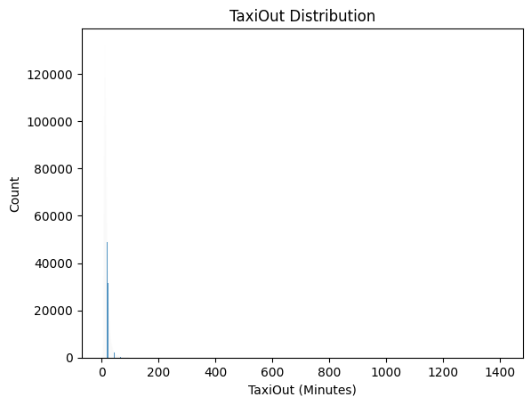

```python
sns.histplot(data=df , x='TaxiOut', color='tab:blue');
# set the title and labels
plt.title('TaxiOut Distribution');
plt.xlabel('TaxiOut (Minutes)');
plt.ylabel('Count');
plt.show();
```

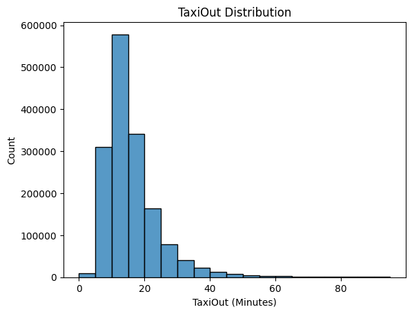

```python
# Set bins to 100 to see more information about the distribution
bins = np.arange(0,100,5)
sns.histplot(data=df , x='TaxiOut', color='tab:blue',bins=bins);
# Set the title and labels
plt.title('TaxiOut Distribution');
plt.xlabel('TaxiOut (Minutes)');
plt.ylabel('Count');
plt.show();
```

This chart have values only between almost 0 , 100 so I setted bins to be between 0 to 100 and steps 5 to show more information to this chart, Also This distribution is right skewed that's mean mode < mean, that's also means mode will be less than 40 like we are seeing

I want to see count of flights in several hours

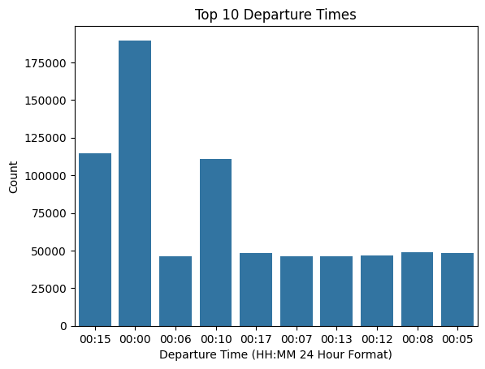

```python
# filter the data to get the most 10 Departure Time there are flights in it
top_10_CRS_dep_time_hours = df['CRSDepTime'].value_counts().head(10).index
# filter the data
filtered_df = df[df['CRSDepTime'].isin(top_10_CRS_dep_time_hours)]
# plot the data
sns.countplot(data=filtered_df, x='CRSDepTime', color='tab:blue');
# set the title and labels
plt.title('Top 10 Departure Times');
plt.xlabel('Departure Time (HH:MM 24 Hour Format)');
plt.ylabel('Count');
plt.show();
```

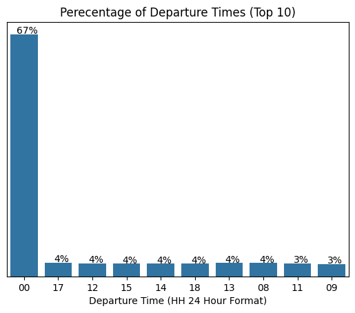

```python
# get only count of hours
CRS_dep_time_hours = df['CRSDepTime'].str.split(':').str[0]
# filter the data
filtered_df = df.loc[CRS_dep_time_hours.index]
# show only hours and limit it to 10 to avoid overplotting
filtered_df = filtered_df[CRS_dep_time_hours.isin(CRS_dep_time_hours.value_counts().head(10).index)]
CRSDepTime_hours = filtered_df['CRSDepTime'].str.split(':').str[0]
# # plot the data
ax = sns.countplot(x=CRSDepTime_hours, color='tab:blue');
# set perentage above each bar
for i,patch in enumerate(ax.patches):
    ax.text(patch.get_x() + patch.get_width()/2 + 0.1 , patch.get_height() + 2000 ,
            str(int(round((CRSDepTime_hours.value_counts()[i] / CRSDepTime_hours.shape[0])*100, 0))) + '%', ha='center');
#hiding y axis
ax.yaxis.set_visible(False)
# set the title and labels
plt.title('Perecentage of Departure Times (Top 10)');
plt.xlabel('Departure Time (HH 24 Hour Format)');
plt.show();
```

I filtered only top 10 hours to avoid overplotting and convert valus to percentages because of large values, also i put values above bars and removed y axis

```python
def optimized_countplot(col , figure_name , title , xlabel):
    # plot the data
    ax = sns.countplot(data=df , x=f'{col}' , color='tab:blue' , order=df[f'{col}'].value_counts().index);# order the data to get the most frequent values to avoid wrong position of percentages
    # set percentage above each bar
    for i,patch in enumerate(ax.patches):
        ax.text(patch.get_x() + patch.get_width()/2 , patch.get_height() + 2000 ,
                str(int(round((df[f'{col}'].value_counts()[i] / df[f'{col}'].shape[0])*100, 0)) )+ '%', ha='center');
    #hiding y axis
    ax.yaxis.set_visible(False)
    # set the title and labels
    plt.title(title);
    plt.xlabel(xlabel);
    plt.show()
```

This function make countplot have perecntage of values above each bar and remove y axis and give title and xlabel

I also want to see count of cancelled flights

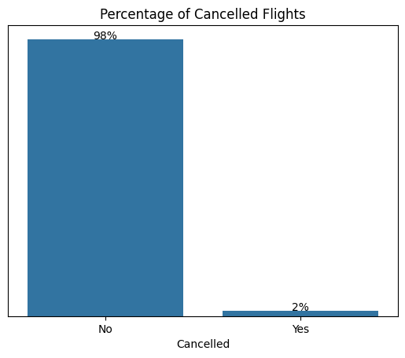

```python
optimized_countplot('Cancelled' , 'Cancelled_Flights' , 'Percentage of Cancelled Flights' , 'Cancelled');
```

What about perentage of Deverted flights

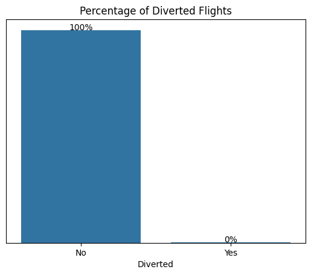

```python
optimized_countplot('Diverted' , 'Diverted_Flights' , 'Percentage of Diverted Flights' , 'Diverted');
```

Let's see count of departure delay time < 15 minutes

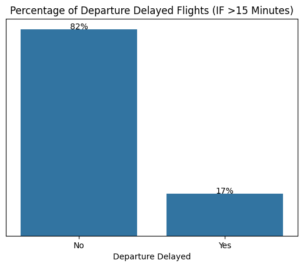

```python
optimized_countplot('DepDel15' , 'Departure_Delayed_Flights' , 'Percentage of Departure Delayed Flights (IF >15 Minutes)' , 'Departure Delayed');
```

### Discussing the distribution(s) of my variable(s) of interest. Were there any unusual points? Did I need to perform any transformations?

> Yes, there were in the second chart all hours are almost similar in percentage but 00 (12 AM) have 67% from the all data  
> No, I don't but I converted all barplots (countplots) values to percentage becuase of large values

### Of the features my investigated, were there any unusual distributions? Did I perform any operations on the data to tidy, adjust, or change the form of the data? If so, why did I do this?

> NO, there weren't  
> Yes, I did in second chart and converted values to only hours to get all values of each hour to get more information about it

## Bivariate Exploration

I want to see relationship between Taxi on and off

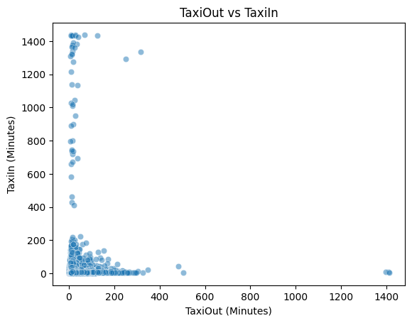

```python
sns.scatterplot(data=df , x='TaxiOut', y='TaxiIn' , alpha=0.5);
# set the title and labels
plt.title('TaxiOut vs TaxiIn');
plt.xlabel('TaxiOut (Minutes)');
plt.ylabel('TaxiIn (Minutes)');
plt.show();
```

I want to make boxplot for distances in each destinations from washington

```python
filtered_df = df[df['OriginCityName'] == 'Washington, DC']
```

```python
filtered_df['OriginCityName'].unique()
```

```
array(['Washington, DC'], dtype=object)
```

Filter only top 5 repeated in our dataset

```python
filtered_df = filtered_df[filtered_df['Dest'].isin(filtered_df['Dest'].value_counts().head(5).index)]
```

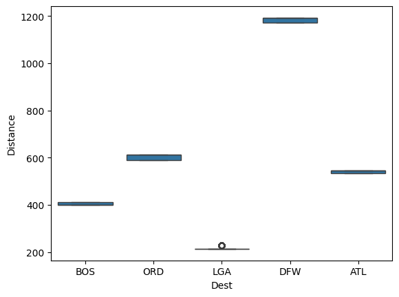

```python
#plotting the data
sns.boxplot(data=filtered_df , x='Dest' , y='Distance' , color='tab:blue');
```

- As we are seeing only destnation have outlire LGA (LaGuardia Airport) in new york

### Did I observe any interesting relationships between the other features (not the main feature(s) of interest)?

> yes, I did, In the first I would make scatterplot to get relationship between CRS departure time and ActuaL departure time, but I maked relationship between Taxi In and Out

## Multivariate Exploration

```python
df['Quarter'].unique()
```

```
array(['January 1-March 31', 'April 1-June 30', 'July 1-September 30',
       'October 1-December 31'], dtype=object)
```

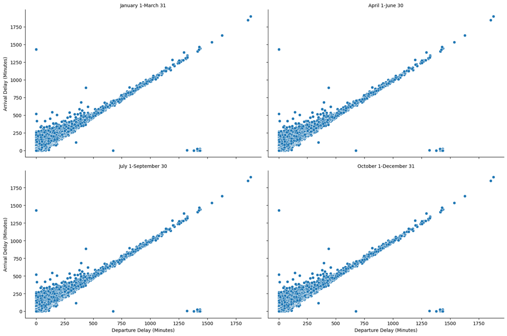

```python
g= sns.FacetGrid(data=df , col='Quarter' , col_wrap=2 , height=5 , aspect=1.5); # Facet grid to plot the data
g.map(sns.scatterplot , x='DepDelayMinutes' , y='ArrDelayMinutes' , data=df, color='tab:blue'); # get relation between Arrival and Departure delays in each quarter
g.set_titles('{col_name}'); # set the title of each plot
g.set_axis_labels('Departure Delay (Minutes)' , 'Arrival Delay (Minutes)'); # set the labels of each plot
plt.show();
```

## Conclusions

> In this dataset I'm get some results about taxi out disterbution and relationship between it and taxi in, also I'm get some results about percentage of devirted flights and also cancelled flights